# `Project 7 - Computer Vision`

# 2. Data Pre-processing: (15 marks)

```python
label_dict =  {0:'Small-flowered Cranesbill', 1:'Fat Hen', 2:'Shepherds Purse', 3:'Common wheat', 4:'Common Chickweed', 5:'Charlock',
               6:'Cleavers', 7:'Scentless Mayweed', 8:'Sugar beet', 9:'Maize',10:'Black-grass', 11: 'Loose Silky-bent'}
```

```python
X= images
Y = Labels
```

```python
print(len(X)) # Check the number of rows in the dataset.
print(X.shape) # The shape of dataset tells us that there are 4750 numbers, each of which has 128*128 pixels and 3 channels. (It's the shape of the numpy array)
```

```
4750
(4750, 128, 128, 3)
```

```python
# Now we create an empty numpy array, which will be used to store the new values after applying Gaussian Blurring filter to the original image.
new_X = np.empty((4750, 128, 128,3))
```

```python
new_X.shape
```

```
(4750, 128, 128, 3)
```

```python
new_X=X.astype('float32')/255 #Normalization
```

```python
# Now we apply the gaussian blur to each 128x128 pixels array (image) to reduce the noise in the image
for i, img in enumerate(new_X):
  new_X[i] = cv2.GaussianBlur(img, (5, 5), 0)
```

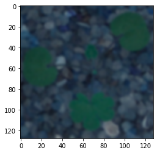

```python
# Plot the de-noised image generated by applying Gaussian blur.
plt.imshow(new_X[1], cmap='gray')
#plt.title(y[i])
```

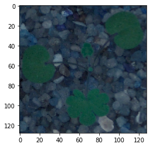

```python
# Plot the de-noised image generated by applying Gaussian blur.
plt.imshow(X[1], cmap='gray')
#plt.title(y[i])
```

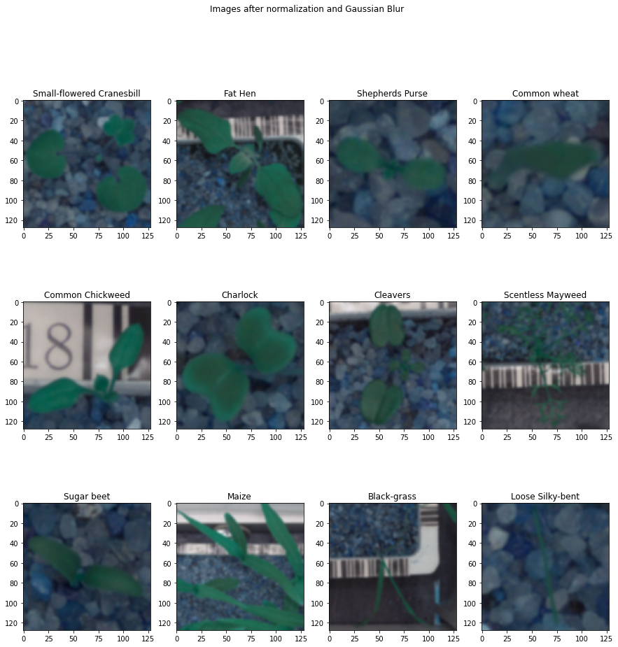

```python
fig, axarr = plt.subplots(3,4, figsize=(15, 15))
fig.suptitle('Images after normalization and Gaussian Blur')
axarr[0,0] .imshow(new_X[495], cmap='gray')
axarr[0,0] .set_title(Labels['Label'].values[495])
axarr[0,1] .imshow(new_X[495+465], cmap='gray')
axarr[0,1] .set_title(Labels['Label'].values[495+465])
axarr[0,2] .imshow(new_X[971+ 230 ], cmap='gray')
axarr[0,2] .set_title(Labels['Label'].values[971+ 230])
axarr[0,3] .imshow(new_X[1202+220], cmap='gray')
axarr[0,3] .set_title(Labels['Label'].values[1202+220])
axarr[1,0] .imshow(new_X[1423+610], cmap='gray')
axarr[1,0] .set_title(Labels['Label'].values[1423+610])
axarr[1,1] .imshow(new_X[2034+380], cmap='gray')
axarr[1,1] .set_title(Labels['Label'].values[2034+380])
axarr[1,2] .imshow(new_X[2424+286], cmap='gray')
axarr[1,2] .set_title(Labels['Label'].values[2424+286])
axarr[1,3] .imshow(new_X[2711+515], cmap='gray')
axarr[1,3] .set_title(Labels['Label'].values[2711+515])
axarr[2,0] .imshow(new_X[3227+384], cmap='gray')
axarr[2,0] .set_title(Labels['Label'].values[3227+384])
axarr[2,1] .imshow(new_X[3612+220], cmap='gray')
axarr[2,1] .set_title(Labels['Label'].values[3612+220])
axarr[2,2] .imshow(new_X[3833+260], cmap='gray')
axarr[2,2] .set_title(Labels['Label'].values[3833+260])
axarr[2,3] .imshow(new_X[4096+650], cmap='gray')
axarr[2,3] .set_title(Labels['Label'].values[4096+650])
```

**The code in the cell below was taken from internet. I combined different sources to try to reproduce it. and I worked for me but only in 1 image.**

```python
def create_mask_for_plant(images):
    image_hsv = cv2.cvtColor(images, cv2.COLOR_BGR2HSV)

    sensitivity = 35
    lower_hsv = np.array([60 - sensitivity, 100, 50])
    upper_hsv = np.array([60 + sensitivity, 255, 255])

    mask = cv2.inRange(image_hsv, lower_hsv, upper_hsv)
    kernel = cv2.getStructuringElement(cv2.MORPH_ELLIPSE, (11,11))
    mask = cv2.morphologyEx(mask, cv2.MORPH_CLOSE, kernel)

    return mask

def segment_plant(images):
    mask = create_mask_for_plant(images)
    output = cv2.bitwise_and(images, images, mask = mask)
    return output

def sharpen_image(images):
    image_blurred = cv2.GaussianBlur(images, (0, 0), 3)
    image_sharp = cv2.addWeighted(images, 1.5, image_blurred, -0.5, 0)
    return image_sharp
```

```python
sensitivity = 35
lower_hsv = np.array([60 - sensitivity, 100, 50])
upper_hsv = np.array([60 + sensitivity, 255, 255])
```

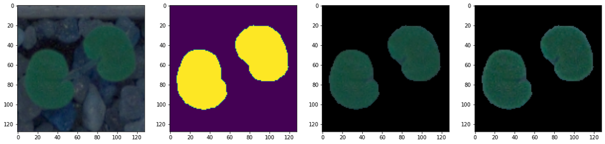

```python
# Test image to see the changes
#image = images_per_class["Small-flowered Cranesbill"][97]
image = images[97]

image_mask = create_mask_for_plant(image)
image_segmented = segment_plant(image)
image_sharpen = sharpen_image(image_segmented)

fig, axs = plt.subplots(1, 4, figsize=(20, 20))
axs[0].imshow(image)
axs[1].imshow(image_mask)
axs[2].imshow(image_segmented)
axs[3].imshow(image_sharpen)#
```

**After this step we can see that the image on the right is more recognizable than the original image on the left**

```python
for i,image in enumerate(images): # With this code I tried to apply the mask to the dataset without success. I decided to keep in the code for refence in the future.
  image_mask = create_mask_for_plant(image)
  image_segmented = segment_plant(image)
  image_sharpen = sharpen_image(image_segmented)
  X_sharpen[i]= image_sharpen
```

```python
# Now we create another empty numpy array of 4750 rows and 128*128 columns shape, to store the pixel values, which are obtained by applying the Gaussian Blur.
# The new array is necessary as we have to feed the data in the model in this original format.
another_X = np.empty((4750, 128*128*3))
```

```python
# Append/Set the values of the another array to be fed into model equal to the flattened array, which has the shape of 784 pixels (1-D)
for i, img in enumerate(new_X):
  another_X[i] = img.flatten()
```

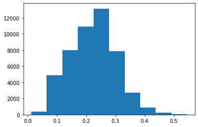

```python
plt.hist(another_X[1])
```

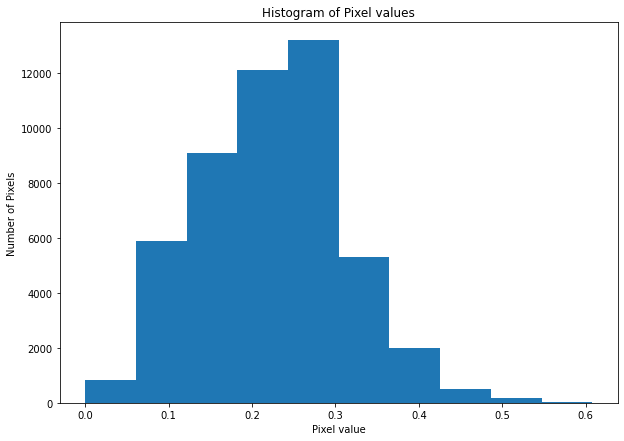

```python
i=1                             # this is to compare the histograme above with the original image#1 in the dataset
img = X[i]
img = img.reshape((128*128*3))/255
plt.figure(figsize=(10,7), edgecolor='blue')

counts, bins, bars = plt.hist(img)
plt.xlabel('Pixel value')
plt.ylabel('Number of Pixels')
plt.title('Histogram of Pixel values')
plt.show()
```

**From the above histogram we can clearly see that after application of Gaussian blur, the image is changed just a little (hard to see the difference). Still it is possible to see some difference in the histogram**

# 3. Make data compatible: (10 marks)

## a. Convert labels to one-hot-vectors.

```python
Y.shape #This is the dataset for Labels defined at the begging of the section 2
```

```
(4750, 1)
```

```python
# Convert labels to one hot vectors as learned on the mentor session

from sklearn.preprocessing import LabelBinarizer
enc = LabelBinarizer()
Y= enc.fit_transform(Y)
```

```python
print(Y.shape)
```

```
(4750, 12)
```

## b. Print the label for y_train[0]

```python
Y[0] # at this point still I haven't split the data, after i do it i will prin y_train [0]
```

```
array([0, 0, 0, 0, 0, 0, 0, 0, 0, 0, 1, 0])
```

## c. Split the dataset into training, testing, and validation set.

```python
# I used a 70% - 30% test train split,
# Note that we used the same Y (labels) as originally since there is no connection between the Gaussian blur and the labels.
X_train, X_test, Y_train, Y_test = train_test_split(another_X, Y, test_size=0.30, random_state=0)
```

```python
# Print the shape of dataset.
print('X_train shape:', X_train.shape)
print(X_train.shape[0], 'train samples')
print(X_test.shape[0], 'test samples')
print ()
print('Y_train shape:', Y_train.shape)
print(Y_train.shape[0], 'train samples')
print(Y_test.shape[0], 'test samples')
```

```
X_train shape: (3325, 49152)
3325 train samples
1425 test samples

Y_train shape: (3325, 12)
3325 train samples
1425 test samples
```

```python
# Reshape train and test sets into compatible shapes
# Sequential model in tensorflow.keras expects data to be in the format (n_e, n_h, n_w, n_c)
# n_e= number of examples, n_h = height, n_w = width, n_c = number of channels
# We don't need to reshape labels sin it is in the format that Kears is expecting

X_train = X_train.reshape(X_train.shape[0], 128, 128, 3)
X_test = X_test.reshape(X_test.shape[0], 128, 128, 3)
```

```python
print("X_train shape:", X_train.shape)
print("Images in X_train:", X_train.shape[0])
print("Images in X_test:", X_test.shape[0])
print("Max value in X_train:", X_train.max())
print("Min value in X_train:", X_train.min())
```

```
X_train shape: (3325, 128, 128, 3)
Images in X_train: 3325
Images in X_test: 1425
Max value in X_train: 0.9990349411964417
Min value in X_train: 0.0
```

```python
print(X_train.shape)
print(Y_train.shape)
print ()
print("Shape of y_train:", Y_train.shape)
print("One value of y_train:", Y_train[0]) ##### ---->>> this was the question 3 section b  <<<< -----####
```

```
(3325, 128, 128, 3)
(3325, 12)

Shape of y_train: (3325, 12)
One value of y_train: [1 0 0 0 0 0 0 0 0 0 0 0]
```

# 4. Building CNN: (15 marks)

```python
from tensorflow.keras.callbacks import ModelCheckpoint, EarlyStopping
```

```python
from keras.layers.convolutional import Conv2D, MaxPooling2D
from keras.models import Sequential
from keras.layers import Dense, Activation, Flatten
```

```python
from tensorflow.keras import datasets, models, layers, optimizers
from tensorflow.keras.preprocessing.image import ImageDataGenerator
from tensorflow.keras.callbacks import ModelCheckpoint, EarlyStopping
from google.colab.patches import cv2_imshow
```

```python
import tensorflow as tf
```